# RESETageing training school

June 8/9, 2021

## Overview

## Schedule

### Session 1

- Introduction
- RStudio environment
- First steps
- Data structures

### Session 2

- Loading packages
- Data visualization
- Basic statistics
- Data export

## Session 1

## Aims of the course

### What do we want to achieve by the end of the course?

- Setupped R environment
- Ability to inspect own research data
- Generate figures
- Have a tool at hand for reproducible research

## FAIR Principles

**The principles emphasise machine-actionability (i.e., the capacity of computational systems to find, access, interoperate, and reuse data with none or minimal human intervention).**  
*https://go-fair.org*

- **Findable** (Data can be discover - use repositories, DOI)
- **Accessible** (Data can be made available and processed - use standard data formats)
- **Interoperable** (Data integration and digestion - avoid proprietary software)
- **Reusable** (Data can be reproduced and reused - use proper licenses, add Meta information)

## Galaxy - https://usegalaxy.eu

[figure not shown]

## What is a programming language?

**A programming language is a formal language, which comprises a set of instructions that produce various kinds of output. Programming languages are used in computer programming to implement algorithms.**  
*https://en.wikipedia.org*

- It is a set of written **commands**, **instructions**, and other **syntax** to create a software program.
- It is designed to be easy to read and understand. This allows to write **source code** in a natural fashion, using **logical words and symbols**.

### A software program is comparable to a recipe or a protocol in the lab.

- **The person who writes programs is called:** developer, programmer, scripter, coder
- **Verbs for doing this:** to develop, to program, to script, to code
- **The result of writing a program:** the source code of a software, a program, a script, a tool
- **Examples of popular programming languages:** Java, Perl, Python, C, C++, R, Go

[figure not shown]

What kind of file/filetype is this?

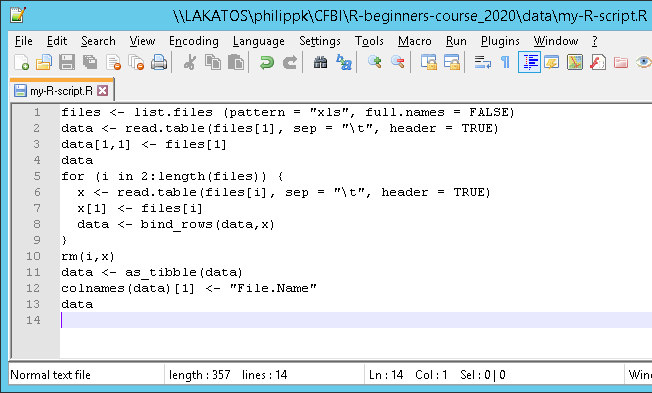

And this?

[figure not shown]

What happened here?

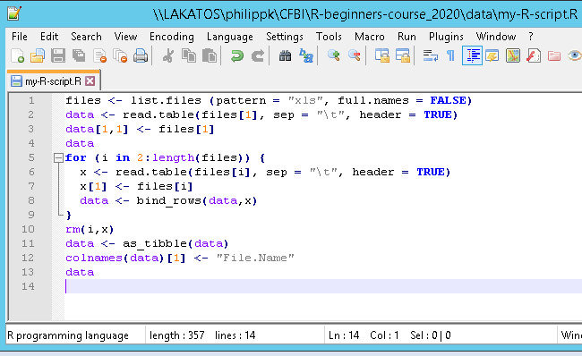

Enabled syntax highlighting!

## What is source code?

- Is **plain text**
- Can be viewed and edited with any text editor on any operating system
- Syntax highlighting is available in specialized editors
- Additional functionality given by integrated development environments (IDE): Eclipse, IntelliJ, RStudio
- RStudio is **one** of the most powerful editors/IDEs for **R**

## What is R and how can it help me?

- Originated in 1993 as the successor of S
- Software environment for statistical computing and graphics
- Free software and extendable via packages (>11,000 on [CRAN](https://cran.r-project.org), >1400 on [Bioconductor](https://bioconductor.org))
- Interpreted language (no compilation needed)
- Object oriented (to some extend)

## What is R and how can it help me?

### Drawbacks

- No paid support like for commercial software
- Reduced or no visual feedback
- Tough entry for beginners
  - Syntax it self
  - Less intuitive data structures compared to other programming languages
  - Many built in keywords and function names (e.g. sum, pi, read, apply, …)

## What is R and how can it help me?

### Advantages

- R allows to analyze complex data and reuse the source code for other projects
- No struggle with very big data files (Excel export limit of 128 data table columns)
- Programmatically create figures
- All-in-one solution when combining packages/Addons
- Makes research more **reproducible**

## RStudio - an IDE for R

### RStudio includes

- An editor that supports
  - Syntax highlighting
  - direct code execution
- A console for code execution
- A workspace to inspect variables
- A viewer for tables, graphics (plots) and help pages
- Package management (addons) and debugging

## Hands-on!

## RStudio - https://live.usegalaxy.eu

[figure not shown]

## RStudio - https://live.usegalaxy.eu

[figure not shown]

## RStudio - https://live.usegalaxy.eu

[figure not shown]

## RStudio - https://live.usegalaxy.eu

[figure not shown]

## RStudio - https://live.usegalaxy.eu

[figure not shown]

## RStudio - https://live.usegalaxy.eu

[figure not shown]

## First steps

- The **Console** is your connection to the R program, it prompts you with `>` to type your command
- type: `1` and press `[RETURN/ENTER]`
- type: `1+1` and press `[RETURN/ENTER]`
- hit up- and down-arrow keys to navigate through your last commands
- use `[ESC]` key to nuke current command line
- **Note**: No error means everything went **syntactically** fine
- type: `abc` and press `[RETURN/ENTER]`

## First steps

**In this presentation:**

- Grey boxes represent Console sections for your hands-on
- `#` introduces a comment which is not interpreted by the R program
- `##` or `## [1]` indicate the output of the R command above

```r
>
> 1+1
## [1] 2
> 5-2 # this is a comment inside the R code
## [1] 3
> pi
## [1] 3.141593
```

## Variables

- In R, all data is stored in variables that represent **Objects** of type list, Number, String, …
- The data (value e.g. `5`), has to be assigned to a variable (e.g. `a`)
- Assignment syntax requires “<-” or “=” (e.g. `a <- 5` or `a = 5`)
- `5 -> a` also works, but `5 = a` not!

## Variables

### Variable names (**name space**)

- can contain letters, numbers, “.” and "_"
- must start with a letter or a dot followed by a letter
- are case sensitive (“a” is not “A”)
- can not use reserved words/builtin functions of R (e.g. the command `pi`)

### One needs to get used **to identify a variable name** in R code

- `variable`
- `x`
- `x1`
- `x1.a`
- `this_is_an_very_informative_but_too_long_variable_name.v1`
- `yet.an.other.style`
- `orEvenTheCamelCaseWay`

## Variables

Type this into the Console of RStudio:

```r
> vari1 <- 3
```

After hitting `[RETURN/ENTER]`, R is **silent**. This means: **everything is fine!**

To see the content of `vari1` type

```r
> vari1
## [1] 3
```

Q: What is the content of `vari2 <- vari1 + 6` ?

```r
> vari2 <- vari1 + 6
> vari2
```

```
## [1] 9
```

## Simple commands (basic maths functions)

We can “do” something with our data. Try these builtin commands:

```r
> abs(3)
> abs(-3)
> log10(100)
> log2(8)
> 2^3
> sqrt(25)
```

Solution:

```r
> abs(3)
## [1] 3
> abs(-3)
## [1] 3
> log10(100)
## [1] 2
> log2(8)
## [1] 3
> 2^3
## [1] 8
> sqrt(25)
## [1] 5
```

## Getting help

- Homepage of the R project https://www.r-project.org/help.html
- Help menu of RStudio
- `?function`
- hit `[F1]` when cursor is inside function name
- Cheat sheets https://rstudio.com/resources/cheatsheets

## RStudio - further functionality

[figure not shown]

## Feedback poll

multiple choice, two questions

http://etc.ch/XtV8

## Exercise 1

- Write some commands in a new empty R script file (editor box in “Source Pane”)
  - File -> New File -> R Script
  - Play around by assigning values to variables
  - Calculate the logarithm of 9 using 3 as the base (hint: `?log` or `[F1]`)
- To execute the commands, you can either …
  - Copy & paste it to the console `[Ctrl]`+`[c]`/`[Ctrl]`+`[v]`
  - Mark it with your mouse or keyboard (`[Shift]`+`[Arrow]`) and press `[Ctrl]`+`[RETURN/ENTER]`
- Find and set your working directory
  - Click on the “Files” tab in the “Viewer Pane”
  - Create a new directory and navigate inot it
  - Hit the gear symbol and select “Set As Working Directory”
- Save your R script
  - To a file: e.g. “my_first_script.R”
  - Download it

## Data structures and import

## Data structures

For sure our scientific data is more complex than a single value, so it needs to be **structured**

### “Every day” data structures

- Yes/No | 1/0
- A single letter/number
- A word/Phone number
- Translation (like in a dictionary, one to many)
- Digital photography (pixel color values)
- Table (like in Excel)

### R data structures

- logical/boolean
- (scalar)
- vector
- list
- matrix
- data frame

## Vector - creation

- Vectors are the most basic data structure after scalars
- Can be created with the concatenation function `c()` (hint: `?c`)

```r
> vector.c <- c(1, 2, 3, 4, 5)  # create
> vector.c  # output the content
## [1] 1 2 3 4 5
>
> animals <- c("cat", "sheep", "dog")  # create
> animals   # output the content
## [1] "cat"   "sheep" "dog"
```

## Vector - creation

- There are further ways to construct a vector by using either the
  - sequence notation
  - `rep()` function

```r
> vector.s <- 1:5  # create
> vector.s  # output the content
## [1] 1 2 3 4 5
>
> vector.r <- rep(1,5)  # create
> vector.r  # output the content
## [1] 1 1 1 1 1
```

Q: How does `rep()` work?

A: Execute: `?rep`

## Vector - creation

- Vectors can be built from other vectors or scalars

```r
> vector.cr <- c(vector.c, vector.r)
> vector.cr
##  [1] 1 2 3 4 5 1 1 1 1 1
>
> vector.cs <- c(vector.c, 6)
> vector.cs
## [1] 1 2 3 4 5 6
```

## Data types

- Data structures store values of a specific type
- Data types can be changes (to some extend)

```r
> vector.c <- c(1, 2, 3, 4, 5)
> typeof(vector.c)  # output the values type
## [1] "double"
> str(vector.c)     # textual representation of the data structure
##  num [1:5] 1 2 3 4 5
>
> animals <- c("cat", "sheep", "dog")
> typeof(animals)   # output the values type
## [1] "character"
> str(animals)      # textual representation of the data structure
##  chr [1:3] "cat" "sheep" "dog"
>
> vector.c <- c("1", "2", "3", "4", "5")
> typeof(vector.c)
## [1] "character"
> vector.c <- as.double(vector.c) # change the values type
> typeof(vector.c)
## [1] "double"
>
> vector.b <- c(TRUE, FALSE, TRUE, FALSE, TRUE)
> vector.b <- c(T, F, T, F, T)
> typeof(vector.b)
## [1] "logical"
```

## Vector - manipulation

```r
> sort(vector.cr)   # Return vector.cr sorted
##  [1] 1 1 1 1 1 1 2 3 4 5
>
> order(vector.cr)  # Return indices of sorted vector.cr
##  [1]  1  6  7  8  9 10  2  3  4  5
>
> rev(vector.cr)    # Return vector.cr reversed
##  [1] 1 1 1 1 1 5 4 3 2 1
>
> unique(vector.cr) # Return unique values
## [1] 1 2 3 4 5
>
> match(animals, c("sheep","cat")) # Return indices of selected elements
## [1]  2  1 NA
```

Q: how many unique elements are in vector.cr?

```r
> v.uniq <- unique(vector.cr)
> v.uniq
## [1] 1 2 3 4 5
> length(v.uniq)
## [1] 5
>
> length( unique(vector.cr) ) # short cut
## [1] 5
```

## Vector - subset

- We can retrieve and change elements of a vector using **square brackets [ ]**.
  - Single elements

```r
> animals # output/return all elements
## [1] "cat"   "sheep" "dog"
>
> animals[2] # give the second element
## [1] "sheep"
>
> animals[3] <- "fish" # replace third element
> animals
## [1] "cat"   "sheep" "fish"
>
> animals[4] <- "elephant" # add a forth element
> animals
## [1] "cat"      "sheep"    "fish"     "elephant"
>
> animals[length(animals)+1] <- "horse" # add a fifth element programmatically
> animals
## [1] "cat"      "sheep"    "fish"     "elephant" "horse"
```

## Vector - subset

- We can retrieve and change elements of a vector using **square brackets [ ]**.
  - Single elements
  - Ranges of elements

```r
> animals # output/return all elements
## [1] "cat"      "sheep"    "fish"     "elephant" "horse"
>
> animals[2:3] # give the second and third element
## [1] "sheep" "fish"
>
> animals[c(2,3)] # give the second and third element
## [1] "sheep" "fish"
>
> animals[c(2,2)] # give the second element twice
## [1] "sheep" "sheep"
>
> animals[rep(2,3)] # give the second element three times
## [1] "sheep" "sheep" "sheep"
```

## Vector - subset

- We can retrieve and change elements of a vector using **square brackets [ ]**.
  - Single elements
  - Ranges of elements
  - Logical selection

```r
> animals # output/return all elements
## [1] "cat"      "sheep"    "fish"     "elephant" "horse"
>
> animals[c(T, F, T, F, T)] # give all elements at un-even indices
## [1] "cat"   "fish"  "horse"
>
> match(animals, c("cat","dog")) # find elements
## [1]  1 NA NA NA NA
> ! is.na(match(animals, c("cat","dog"))) # generate logical vector
## [1]  TRUE FALSE FALSE FALSE FALSE
> animals[! is.na(match(animals, c("cat","dog")))]
## [1] "cat"
```

## The vectorized concept of R

- Vectors can be combined in a comfortable way
- Operations are applied element wise

```r
> l <- c(T,F,T)
> a <- c(1,1,1)
> b <- c(1,2,4)
```

Q: What will be the output?

```r
> ! l
> a == 1
> ! a == 1
> b < 2
> b >= 2
> a+b
> a-b
> a*b
> a/b
> log2(b)
> sum(a,b)
```

## The vectorized concept of R

```r
> l <- c(T,F,T)
> a <- c(1,1,1)
> b <- c(1,2,4)
>
> ! l
## [1] FALSE  TRUE FALSE
> a == 1
## [1] TRUE TRUE TRUE
> ! a == 1
## [1] FALSE FALSE FALSE
> b < 2
## [1]  TRUE FALSE FALSE
> b >= 2
## [1] FALSE  TRUE  TRUE
> a+b
## [1] 2 3 5
> a-b
## [1]  0 -1 -3
> a*b
## [1] 1 2 4
> a/b
## [1] 1.00 0.50 0.25
> log2(b)
## [1] 0 1 2
> sum(a,b)
## [1] 10
```

## Feedback poll

multiple choice, two questions

http://etc.ch/XtV8

## Exercise 2

After you learned how to build a vector, let’s build a longer one. Create a new vector `long` with length 96 that contains the elements of `b` as follows:  
1, 2, 3, 1, 2, 3, …, 1, 2, 3

For this, you may use the …

- assignment operator `<-`
- `c()` function
- You are allowed to create new vectors that may help you.

## Exercise 2 - Solutions

```r
> b <- c(1,2,3)
> long <- (c(b,b,b,b,b,b,b,b,b,b,b,b,b,b,b,b,b,b,b,b,b,b,b,b,b,b,b,b,b,b,b,b))
> length(long) # (3*32)
## [1] 96
```

```r
> tmp <- c(b,b,b,b)
> long <- c(tmp, tmp, tmp, tmp, tmp, tmp, tmp, tmp)
> length(long) # ((3*4)*8)
## [1] 96
```

```r
> b <- c(b,b)
> b <- c(b,b)
> b <- c(b,b)
> b <- c(b,b)
> long <- c(b,b)
> length(long) # (((((3*2)*2)*2)*2)*2)
## [1] 96
```

```r
> b <- c(1,2,3)
> long <- rep(b,32)
```

## List - creation

- A list is an object that contains other objects as pairs of a **key** and a **value**
- The internal objects can be of different data types
- The internal vectors can be of different lengths
  - Very different to data frames and matrices!

```r
> names <- c("Jane", "Tarzan", "Mowgli")  # a character vector
> ages <- c(24, 25, 7)                    # a double vector
>
> jungle.people <- list("name" = names, "age" = ages) # a list of two keys and vectors
>
> jungle.people         # let's see how it looks like
## $name
## [1] "Jane"   "Tarzan" "Mowgli"
##
## $age
## [1] 24 25  7
>
> typeof(jungle.people) # returns the object type
## [1] "list"
> str(jungle.people)    # get more structured information with str()
## List of 2
##  $ name: chr [1:3] "Jane" "Tarzan" "Mowgli"
##  $ age : num [1:3] 24 25 7
```

## List - subset

Access list objects by using **double square bracket** `[[]]` or **dollar sign** `$` notation

```r
> jungle.people[[1]]      # returns a character vector
## [1] "Jane"   "Tarzan" "Mowgli"
>
> jungle.people[["name"]] # returns the same character vector
## [1] "Jane"   "Tarzan" "Mowgli"
>
> jungle.people$name      # returns also the same character vector
## [1] "Jane"   "Tarzan" "Mowgli"
```

Append an other vector to a list

```r
> raised.by.wolves <- c(FALSE, FALSE, TRUE) # a simple logical vector
>
> jungle.people[["raisedByWolves"]] <- raised.by.wolves # add the vector as a new element to the list
> str(jungle.people)
## List of 3
##  $ name          : chr [1:3] "Jane" "Tarzan" "Mowgli"
##  $ age           : num [1:3] 24 25 7
##  $ raisedByWolves: logi [1:3] FALSE FALSE TRUE
>
> jungle.people[["raisedByWolves"]]         # also possible: jungle.people$raisedByWolves
## [1] FALSE FALSE  TRUE
```

## List - manipulation

- Vector functions can not be applied to internal list objects directly
- Instead, iterate over each key and apply a certain function per vector

```r
> sort(names)
## [1] "Jane"   "Mowgli" "Tarzan"
> sort(ages)
## [1]  7 24 25
>
> lapply(jungle.people, sort) # list apply
## $name
## [1] "Jane"   "Mowgli" "Tarzan"
##
## $age
## [1]  7 24 25
##
## $raisedByWolves
## [1] FALSE FALSE  TRUE
> lapply(jungle.people, order)
## $name
## [1] 1 3 2
##
## $age
## [1] 3 1 2
##
## $raisedByWolves
## [1] 1 2 3
> lapply(jungle.people, rev)
## $name
## [1] "Mowgli" "Tarzan" "Jane"
##
## $age
## [1]  7 25 24
##
## $raisedByWolves
## [1]  TRUE FALSE FALSE
> lapply(jungle.people, unique)
## $name
## [1] "Jane"   "Tarzan" "Mowgli"
##
## $age
## [1] 24 25  7
##
## $raisedByWolves
## [1] FALSE  TRUE
>
> # for more more complex operations, use own, anonymous functions / lambda functions
> lapply(jungle.people, function(x){
+   x[1:2]
+ })
## $name
## [1] "Jane"   "Tarzan"
##
## $age
## [1] 24 25
##
## $raisedByWolves
## [1] FALSE FALSE
```

## Matrix - creation

- A matrix is a **two-dimensional** arrangement of objects
- All objects must be of the **same type**
- Each row must have the same number of columns i.e. values

```r
> # create a 3 by 4 matrix and fill it by columns with the numbers 1 to 12
> mx <- matrix(1:12, nrow=3, ncol=4) # short cut: matrix(1:12, 3, 4)
> mx
##      [,1] [,2] [,3] [,4]
## [1,]    1    4    7   10
## [2,]    2    5    8   11
## [3,]    3    6    9   12
> dim(mx)  # get the dimension of mx
## [1] 3 4
> nrow(mx) # returns the number of rows
## [1] 3
> ncol(mx) # returns the number of columns
## [1] 4
```

```r
> l <- c(LETTERS[1:6],letters[7:12]) # builtin vectors
> mx2 <- matrix(l, ncol=3)
> mx2
##      [,1] [,2] [,3]
## [1,] "A"  "E"  "i"
## [2,] "B"  "F"  "j"
## [3,] "C"  "g"  "k"
## [4,] "D"  "h"  "l"
```

## Matrix - creation

- There are further ways to construct a matrix by using
  - the `matrix()` function
  - the `rbind()` or `cbind()` functions to paste rows or columns

```r
> v1 <- c(13,14,15)
> v2 <- c(16,17,18)
> rbind(v1,v2)
##    [,1] [,2] [,3]
## v1   13   14   15
## v2   16   17   18
> cbind(v1,v2)
##      v1 v2
## [1,] 13 16
## [2,] 14 17
## [3,] 15 18
>
> cbind(mx,v1) # rbind is not possible!
##               v1
## [1,] 1 4 7 10 13
## [2,] 2 5 8 11 14
## [3,] 3 6 9 12 15
```

## Matrix - subset

- Access matrix objects by using **square brackets [ , ]**.
  - Get single values by row/column coordinates
  - Extract vectors by row or column

```r
> mx
##      [,1] [,2] [,3] [,4]
## [1,]    1    4    7   10
## [2,]    2    5    8   11
## [3,]    3    6    9   12
>
> # subscript access to only a single entry
> mx[1,2] # always: [row,column]
## [1] 4
>
> # subscript access to an entire row or column
> mx[1,]
## [1]  1  4  7 10
> mx[,1]
## [1] 1 2 3
> mx[c(1,2), ]
##      [,1] [,2] [,3] [,4]
## [1,]    1    4    7   10
## [2,]    2    5    8   11
```

## Matrix - manipulation

- Simple operations are applied element wise

```r
> mx
##      [,1] [,2] [,3] [,4]
## [1,]    1    4    7   10
## [2,]    2    5    8   11
## [3,]    3    6    9   12
> mx+1
##      [,1] [,2] [,3] [,4]
## [1,]    2    5    8   11
## [2,]    3    6    9   12
## [3,]    4    7   10   13
> mx*2
##      [,1] [,2] [,3] [,4]
## [1,]    2    8   14   20
## [2,]    4   10   16   22
## [3,]    6   12   18   24
> mx*mx # identical to mx^2
##      [,1] [,2] [,3] [,4]
## [1,]    1   16   49  100
## [2,]    4   25   64  121
## [3,]    9   36   81  144
```

## Matrix - manipulation

- Matrix operations and builtin functions
  - `%*%`
  - `t()` function transposes a matrix

```r
> mx
##      [,1] [,2] [,3] [,4]
## [1,]    1    4    7   10
## [2,]    2    5    8   11
## [3,]    3    6    9   12
>
> t(mx) %*% mx
##      [,1] [,2] [,3] [,4]
## [1,]   14   32   50   68
## [2,]   32   77  122  167
## [3,]   50  122  194  266
## [4,]   68  167  266  365
>
> t(mx) %*% c(1,2,3)
##      [,1]
## [1,]   14
## [2,]   32
## [3,]   50
## [4,]   68
```

## Matrix - manipulation

- Vector functions can be applied directly - be careful!

```r
> mx3 <- cbind(mx,c(1,2,3))
> mx3 <- t(mx3)
> mx3
##      [,1] [,2] [,3]
## [1,]    1    2    3
## [2,]    4    5    6
## [3,]    7    8    9
## [4,]   10   11   12
## [5,]    1    2    3
>
> sum(mx3)    # returns a scalar
## [1] 84
> sort(mx3)   # returns a vector
##  [1]  1  1  2  2  3  3  4  5  6  7  8  9 10 11 12
> rev(mx3)    # returns a vector
##  [1]  3 12  9  6  3  2 11  8  5  2  1 10  7  4  1
> unique(mx3) # returns a matrix
##      [,1] [,2] [,3]
## [1,]    1    2    3
## [2,]    4    5    6
## [3,]    7    8    9
## [4,]   10   11   12
```

## Matrix - manipulation

- Otherwise, iterate over each row or column and apply a certain function to the vector

```r
> mx
##      [,1] [,2] [,3] [,4]
## [1,]    1    4    7   10
## [2,]    2    5    8   11
## [3,]    3    6    9   12
>
> apply(mx, 1, sum) # row sums
## [1] 22 26 30
> apply(mx, 2, sum) # column sums
## [1]  6 15 24 33
>
> # for more more complex operations, use own, anonymous functions / lambda functions
> t(apply(mx, 1, function(x){
+   x[1:2]
+ }))
##      [,1] [,2]
## [1,]    1    4
## [2,]    2    5
## [3,]    3    6
```

## Data frame - creation

- Similar to matrices
  - A data frame is a **two-dimensional** arrangement of objects with same number of columns per row

```r
> vf <- c("apple","banana","strawberry","lemmon")
> vc <- c("green","yellow","red","yellow")
> df <- data.frame(fruit = vf, color = vc, taste = c("sweet","sweet","sweet","sour") )
> df
##        fruit  color taste
## 1      apple  green sweet
## 2     banana yellow sweet
## 3 strawberry    red sweet
## 4     lemmon yellow  sour
>
> as.data.frame(mx)
##   V1 V2 V3 V4
## 1  1  4  7 10
## 2  2  5  8 11
## 3  3  6  9 12
>
> as.matrix(df)
##      fruit        color    taste
## [1,] "apple"      "green"  "sweet"
## [2,] "banana"     "yellow" "sweet"
## [3,] "strawberry" "red"    "sweet"
## [4,] "lemmon"     "yellow" "sour"
```

## Data frame - creation

- Similar to lists
  - Each column can be a different data type
  - All objects within one column must be of the same type

```r
> as.data.frame(jungle.people)
##     name age raisedByWolves
## 1   Jane  24          FALSE
## 2 Tarzan  25          FALSE
## 3 Mowgli   7           TRUE
>
> as.list(df)
## $fruit
## [1] "apple"      "banana"     "strawberry" "lemmon"
##
## $color
## [1] "green"  "yellow" "red"    "yellow"
##
## $taste
## [1] "sweet" "sweet" "sweet" "sour"
```

## Data frame - subset

- Access data frame objects
  - Similar to matrices by using **square brackets [ , ]**.
  - Similar to lists by using **dollar sign** `$` notation

```r
> df
##        fruit  color taste
## 1      apple  green sweet
## 2     banana yellow sweet
## 3 strawberry    red sweet
## 4     lemmon yellow  sour
>
> df[1,2]
## [1] "green"
>
> df$fruit
## [1] "apple"      "banana"     "strawberry" "lemmon"
> df[,1]
## [1] "apple"      "banana"     "strawberry" "lemmon"
> df[,"fruit"]
## [1] "apple"      "banana"     "strawberry" "lemmon"
>
> df[df$color == "yellow", ]
##    fruit  color taste
## 2 banana yellow sweet
## 4 lemmon yellow  sour
```

## Data frame - subset

- Access data frame objects
  - Similar to matrices by using **square brackets [ , ]**.
  - Similar to lists by using **dollar sign** `$` notation

```r
> df
##        fruit  color taste
## 1      apple  green sweet
## 2     banana yellow sweet
## 3 strawberry    red sweet
## 4     lemmon yellow  sour
>
> df[c(1,2),]
##    fruit  color taste
## 1  apple  green sweet
## 2 banana yellow sweet
>
> df[c(1,2),c("fruit","taste")]
##    fruit taste
## 1  apple sweet
## 2 banana sweet
```

## Data frame - subset

Append an other vector to the data frame

```r
> df$in.stock <- c(25,33,0,156)
> df
##        fruit  color taste in.stock
## 1      apple  green sweet       25
## 2     banana yellow sweet       33
## 3 strawberry    red sweet        0
## 4     lemmon yellow  sour      156
>
> df <- cbind(df,c(F,F,T,T))
> colnames(df)[ncol(df)] = "favorite"
> df
##        fruit  color taste in.stock favorite
## 1      apple  green sweet       25    FALSE
## 2     banana yellow sweet       33    FALSE
## 3 strawberry    red sweet        0     TRUE
## 4     lemmon yellow  sour      156     TRUE
```

## Data frame - manipulation

- Nearly identical to matrices manipulation

```r
> colnames(df)  # set or get all column names of the df
## [1] "fruit"    "color"    "taste"    "in.stock" "favorite"
>
> rownames(df)  # set or get all column names of the df
## [1] "1" "2" "3" "4"
>
> length(df)    # careful! It is the number of columns!
## [1] 5
>
> dim(df)       # this returns a vector of both, row number and column number
## [1] 4 5
>
> nrow(df)      # number of rows, like in dim(df)[1]
## [1] 4
>
> df$in.stock <- df$in.stock + 20    # we get a new delivery -> all fruits plus 20
```

## Feedback poll

multiple choice, two questions

http://etc.ch/XtV8